# California-Avocado-Analysis

Damar Djati Wahyu Kemala

01 December 2022

### Langkah 1: Import Data

`california_avocados` dataset, Data yang akan diimport menggunakan format csv (comma separated values) yang dimana dataset ini diperoleh dari Kaggle. Link dataset: [California Avocado](https://www.kaggle.com/datasets/jarredpriester/california-avocado-production-19802020)

```r
avocados_data <- read.csv("cali_avocados.csv")
```

### Langkah 2: Melihat Data

Data `California Avocado` terdiri dari 11 kolom dan 420 Baris.

|  | Year | Commodity.Code | Crop.Name | County.Code | County | Harvested.Acres | Yield | Production | Price.P.U | Unit | Value |
| --- | --- | --- | --- | --- | --- | --- | --- | --- | --- | --- | --- |
| 1 | 2020 | 221999 | AVOCADOS ALL | 53 | Monterey | 223 | 5.56 | 1240 | 2379.84 | Tons | 2951000 |
| 2 | 2020 | 221999 | AVOCADOS ALL | 65 | Riverside | 3020 | NA | NA | NA | Tons | 88697000 |
| 3 | 2020 | 221999 | AVOCADOS ALL | 71 | San Bernardino | 370 | 2.16 | 799 | 2617.02 | Tons | 2091000 |
| 4 | 2020 | 221999 | AVOCADOS ALL | 73 | San Diego | 14400 | 3.51 | 50500 | 3028.87 | Tons | 152958000 |
| 5 | 2020 | 221999 | AVOCADOS ALL | 79 | San Luis Obispo | 4240 | 5.90 | 25000 | 1886.76 | Tons | 47169000 |
| 6 | 2020 | 221999 | AVOCADOS ALL | 83 | Santa Barbara | 5770 | 4.89 | 28200 | 2842.59 | Tons | 80161000 |

Melihat daftar kolom yang ada pada dataset `california_avocados`.

```r
colnames(avocados_data)
```

```
 [1] "Year"            "Commodity.Code"  "Crop.Name"       "County.Code"     "County"
 [6] "Harvested.Acres" "Yield"           "Production"      "Price.P.U"       "Unit"
[11] "Value"
```

Mengganti format penamaan kolom yang memuat tanda titik dengan tanda garis bawah.

```r
colnames(avocados_data)[2] = "Commodity_code"
colnames(avocados_data)[3] = "Crop_name"
colnames(avocados_data)[4] = "County_code"
colnames(avocados_data)[6] = "Harvested_Acres"
colnames(avocados_data)[9] = "Price_P/U"
```

Melihat nama kolom setelah dilakukan format.

```r
colnames(avocados_data)
```

```
 [1] "Year"            "Commodity_code"  "Crop_name"       "County_code"     "County"
 [6] "Harvested_Acres" "Yield"           "Production"      "Price_P/U"       "Unit"
[11] "Value"
```

### Langkah 3: Mengunduh dan Menload Package tidyverse & ggplot2

```r
library(tidyverse)
```

### Langkah 4: Mengecek Null Value

Pada langkah ini akan mengecek nilai Null pada setiap kolom data,

```r
summary(avocados_data)
```

```
      Year      Commodity_code    Crop_name          County_code       County
 Min.   :1980   Min.   :221999   Length:420         Min.   :  7.0   Length:420
 1st Qu.:1988   1st Qu.:221999   Class :character   1st Qu.: 59.0   Class :character
 Median :1997   Median :221999   Mode  :character   Median : 73.0   Mode  :character
 Mean   :1998   Mean   :221999                      Mean   :120.3
 3rd Qu.:2008   3rd Qu.:221999                      3rd Qu.: 83.0
 Max.   :2020   Max.   :221999                      Max.   :991.0

 Harvested_Acres       Yield         Production         Price_P/U          Unit
 Min.   :    4.0   Min.   :0.140   Min.   :    29.0   Min.   : 163.0   Length:420
 1st Qu.:  227.5   1st Qu.:1.870   1st Qu.:   826.5   1st Qu.: 877.8   Class :character
 Median : 1581.5   Median :2.900   Median :  5243.5   Median :1618.0   Mode  :character
 Mean   : 6344.1   Mean   :2.938   Mean   : 19203.4   Mean   :1576.2
 3rd Qu.: 8375.2   3rd Qu.:3.850   3rd Qu.: 26340.0   3rd Qu.:2112.3
 Max.   :36800.0   Max.   :8.600   Max.   :160574.0   Max.   :3958.1
 NA's   :18        NA's   :26      NA's   :26         NA's   :26
     Value
 Min.   :     9000
 1st Qu.:   988900
 Median :  8166750
 Mean   : 30823364
 3rd Qu.: 41096800
 Max.   :251452100
 NA's   :18
```

Terdapat nilai Null sebanyak 26 baris data (terbanyak)

### Langkah 5: Menghapus Nilai Null/NA Values

```r
ls()
```

```
[1] "avocados_data"
```

Mengecek Data setelah dilakukan pembersihan N/A Values.

```r
summary(avocados_data_v2)
```

```
      Year      Commodity_code    Crop_name          County_code       County
 Min.   :1980   Min.   :221999   Length:394         Min.   : 19.0   Length:394
 1st Qu.:1988   1st Qu.:221999   Class :character   1st Qu.: 59.0   Class :character
 Median :1998   Median :221999   Mode  :character   Median : 73.0   Mode  :character
 Mean   :1999   Mean   :221999                      Mean   :107.9
 3rd Qu.:2008   3rd Qu.:221999                      3rd Qu.: 83.0
 Max.   :2020   Max.   :221999                      Max.   :991.0
 Harvested_Acres       Yield         Production         Price_P/U          Unit
 Min.   :   31.0   Min.   :0.140   Min.   :    29.0   Min.   : 163.0   Length:394
 1st Qu.:  238.5   1st Qu.:1.870   1st Qu.:   826.5   1st Qu.: 877.8   Class :character
 Median : 1641.5   Median :2.900   Median :  5243.5   Median :1618.0   Mode  :character
 Mean   : 6461.7   Mean   :2.938   Mean   : 19203.4   Mean   :1576.2
 3rd Qu.: 8457.2   3rd Qu.:3.850   3rd Qu.: 26340.0   3rd Qu.:2112.3
 Max.   :36800.0   Max.   :8.600   Max.   :160574.0   Max.   :3958.1
     Value
 Min.   :     9000
 1st Qu.:  1065750
 Median :  8563150
 Mean   : 31211843
 3rd Qu.: 42337550
 Max.   :251452100
```

Data telah bersih dari Null Values. Selanjutnya menghapus kolom yang tidak digunakan untuk analisis.

### Langkah 6: Menghapus Kolom yang Tidak Digunakan untuk Analisis

Kolom `Commodity_code`, `County_code`, `Crop_name`, dan `Value`

```r
colnames(avocados_data_v3)
```

```
[1] "Year"            "County"          "Harvested_Acres" "Yield"           "Production"
[6] "Price_P/U"       "Unit"
```

Melakukan cek data kembali apakah data `california_avocados` sudah dalam format yang baik

|  | Year | County | Harvested_Acres | Yield | Production | Price_P/U | Unit |
| --- | --- | --- | --- | --- | --- | --- | --- |
| 1 | 2020 | Monterey | 223 | 5.56 | 1240 | 2379.84 | Tons |
| 2 | 2020 | San Bernardino | 370 | 2.16 | 799 | 2617.02 | Tons |
| 3 | 2020 | San Diego | 14400 | 3.51 | 50500 | 3028.87 | Tons |
| 4 | 2020 | San Luis Obispo | 4240 | 5.90 | 25000 | 1886.76 | Tons |
| 5 | 2020 | Santa Barbara | 5770 | 4.89 | 28200 | 2842.59 | Tons |
| 6 | 2020 | Ventura | 16400 | 4.29 | 70300 | 2556.57 | Tons |

### Langkah 7: Mengecek Tipe Data Masing-Masing Kolom

Mengetahui tipe data setiap kolom untuk menghindari format tipe data pada kolom yang tidak konsisten.

```r
sapply(avocados_data_v3, class)
```

```
           Year          County Harvested_Acres           Yield      Production
      "numeric"     "character"       "numeric"       "numeric"       "numeric"
      Price_P/U            Unit
      "numeric"     "character"
```

Dari tipe data pada tiap kolom diatas kita perlu mengubah nilai kolom Harvested_Acres dan Production Menjadi tipe Integer.

```r
avocados_data_v3$Harvested_Acres <-as.integer(avocados_data_v3$Harvested_Acres)
avocados_data_v3$Production <-as.integer(avocados_data_v3$Production)
```

Mengecek kembali tipe data pada tiap kolom dataset `california avocados`

```r
sapply(avocados_data_v3, class)
```

```
           Year          County Harvested_Acres           Yield      Production
      "numeric"     "character"       "integer"       "numeric"       "integer"
      Price_P/U            Unit
      "numeric"     "character"
```

|  | Year | County | Harvested_Acres | Yield | Production | Price_P/U | Unit |
| --- | --- | --- | --- | --- | --- | --- | --- |
| 1 | 2020 | Monterey | 223 | 5.56 | 1240 | 2379.84 | Tons |
| 2 | 2020 | San Bernardino | 370 | 2.16 | 799 | 2617.02 | Tons |
| 3 | 2020 | San Diego | 14400 | 3.51 | 50500 | 3028.87 | Tons |
| 4 | 2020 | San Luis Obispo | 4240 | 5.90 | 25000 | 1886.76 | Tons |
| 5 | 2020 | Santa Barbara | 5770 | 4.89 | 28200 | 2842.59 | Tons |
| 6 | 2020 | Ventura | 16400 | 4.29 | 70300 | 2556.57 | Tons |

```r
min(avocados_data_v3$Yield)
```

```
[1] 0.14
```

```r
max(avocados_data_v3$Yield)
```

```
[1] 8.6
```

### Langkah 7: Membuat Chart/Plot

Mengetahui wawasan apa saja yang dapat ditemukan didalam dataset `California_avocados`.

**Pertanyaan:**

**Menjawab Pertanyaan:**

##### 1. Produksi/panen avocado tertinggi pada tahun berapa? (jika diambil 3 tahun terakhir yaitu 2020-2018)?

```r
glimpse(ProductionByYear)
```

```
Rows: 41
Columns: 2
$ total_production <int> 94992, 217254, 224058, 256303, 288289, 231040, 210412, 283313, 2081…
$ year             <fct> 1980, 1981, 1982, 1983, 1984, 1985, 1986, 1987, 1988, 1989, 1990, 1…
```

Hasil visualisasi untuk total produksi selama 3 tahun terakhir.

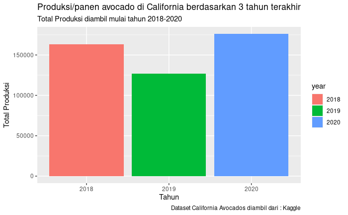

Mengetahui Total Produksi dari tahun 2018 - 2020:

| Tahun | Total_Produksi_Avocado |
| --- | --- |
| 2018 | 163192 |
| 2019 | 127080 |
| 2020 | 176039 |

**Menjawab Pertanyaan:**

```r
glimpse(ProductionByCounty)
```

```
Rows: 23
Columns: 2
$ total_production <int> 5872, 2841, 11156, 3818, 12277, 143111, 70800, 765266, 4919, 28472,…
$ county           <fct> Fresno , Kern , Los Angeles , Monterey, Monterey , Orange , Riversi…
```

```r
glimpse(DataProductionByCounty)
```

```
Rows: 2
Columns: 2
$ Kabupaten        <fct> San Diego , Santa Cruz
$ `Total Produksi` <int> 3043347, 937
```

[figure not shown]

Menampilkan hasil total produksi di kedua kabupaten diatas:

| Kabupaten | Total Produksi |
| --- | --- |
| San Diego | 3043347 |
| Santa Cruz | 937 |